# PERTEMUAN 4

Kheni Hikmah Lestari

2023-08-28

# Pembangkitan data model M(2) dengan theta1=0.4 dan theta2=0.6 sebanyak 300 data secara manual

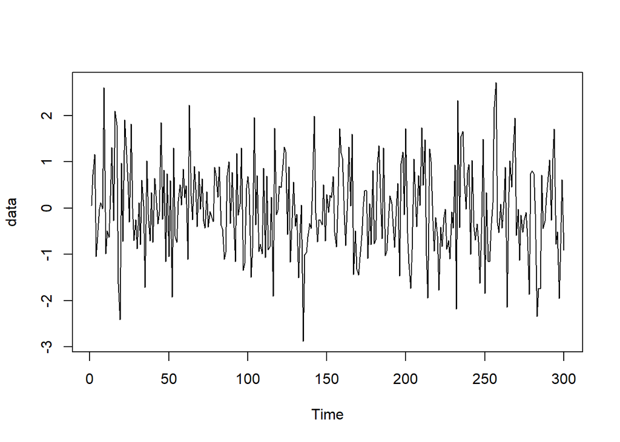

```r
data <- rnorm(300)
ts.plot(data)
```

# Proses MA (2)

Proses MA dapat dituliskan sebagai berikut:

$$y_{t} = c + e_t + \theta_{1}e_{t-1} + \theta_{2}e_{t-2} + \dots +
\theta_{q}e_{t-q} = c+{e_t+\sum_{i=1}^p \theta_ie_{t-i}}$$

Terlihat bahwa $e_t$, atau *white noise*, berperan penting dalam pembangkitan proses MA(2).

## Pembangkitan Proses MA(2) manual

```r
set.seed(1029)
ma <- data[c(1,2)]
ma
```

```
## [1] 0.05624269 0.72243784
```

```r
theta1= 0.4
theta2 =0.6
```

$$y_t = e_t+0.4e_{t-1}+0.6e_{t-2}$$

```r
set.seed(1029)
for(i in 3:300){
   ma[i] <- data[i] + 0.4 * data[i - 1]  + 0.6 * data[i - 2]
}
ma
```

```
##   [1]  0.056242690  0.722437840  1.485684599 -0.153301327 -0.206525293
##   [6] -0.845650817 -0.179951404  0.022588458  2.668715228  0.043118694
##  [11]  0.675973537 -1.424082312 -0.278466988  1.038574138  0.413091595
##  [16]  2.778750055  2.478178424  0.349349946 -1.983418625 -0.965955499
##  [21] -1.778114330  2.202803929  1.677959165  2.263098713  0.745134491
##  [26]  2.048342260  0.543664211  0.393774215 -0.530654491 -1.394946709
##  [31] -0.386799781 -1.266425027  0.359164992 -0.183287967 -1.332413259
##  [36]  0.368112810 -0.754553231 -0.145846756 -0.033264701 -1.034741989
##  [41]  0.542071518  0.073937070  0.153128363 -0.057975679  1.618405666
##  [46]  0.453544522  1.838133576 -0.968339087  0.773371188 -1.447756711
##  [51]  0.615333667 -2.314109084  0.886270230 -1.232107021 -0.196913258
##  [56] -0.511518796  0.124069299  0.352932477  1.173705530  0.598000665
##  [61]  1.078493713 -0.784636183  2.068662583  0.490509574  1.189957875
##  [66]  0.960950084  0.618751156  0.299095999  0.880792844  0.052121224
##  [71]  1.100283676 -0.039135774 -0.158916864  0.020791052 -0.522263969
```

[output cut: 45 more lines]

Selain menggunakan cara di atas, pembangkitan proses MA(2) dapat dilakukan dengan fungsi `arima.sim()` sebagai berikut.

## Menggunakan fungsi Arima.sim()

```r
ma2 <- arima.sim(list(order=c(0,0,2), ma=c(0.4, 0.6)), n=300)
ma2
```

```
## Time Series:
## Start = 1
## End = 300
## Frequency = 1
##   [1] -1.071082769 -0.850804055  0.499757168 -1.282264464 -0.547840914
##   [6] -1.575171808 -2.048969551 -2.635133956 -1.571118561 -1.790433630
##  [11] -1.717066338 -0.556133552  0.072669291  1.929914004  1.622290675
##  [16]  1.146337528  0.859824636  1.116855057 -0.191069929 -0.512269221
##  [21] -1.334764260 -0.621694643 -0.509740435  1.505990240  1.457148632
##  [26] -0.220387312  1.708900173 -1.593188538 -0.457951490 -1.074571780
##  [31] -1.424819544  0.444904719  1.162710619  0.801165189  1.235879033
##  [36]  0.632147482  1.096573788  1.407632885 -1.045479149 -0.070897014
##  [41] -1.294572191 -1.413649335  0.298450337 -1.586486923 -1.553027865
##  [46] -1.772460310  0.126243449 -0.527127135 -0.067794069 -0.241172973
##  [51]  1.021325829 -0.175471645  1.150838818 -0.752948351 -1.013927783
```

[output cut: 49 more lines]

## Buatlah Plot time series, Plot ACF, plot PACF, dan Plot EACF. Identifikasi apakah data tersebut stasioner

### Plot Time Series

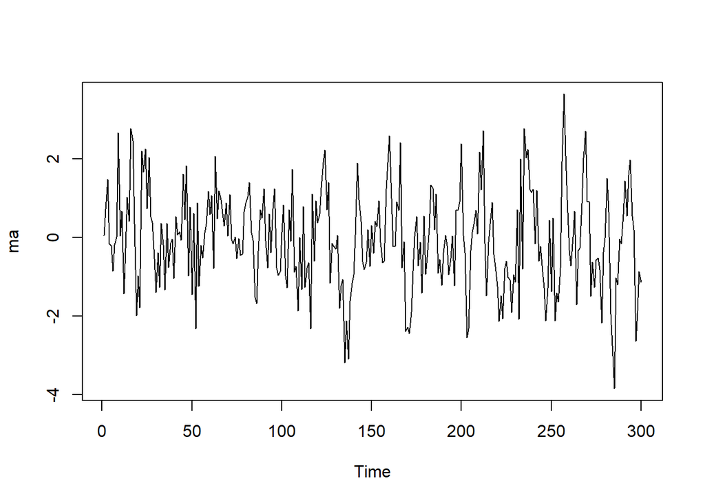

```r
ts.plot(ma)
```

Berdasarkan plot time series, terlihat bahwa data MA(2) yang dibangkitkan stasioner dalam rataan

### Plot ACF

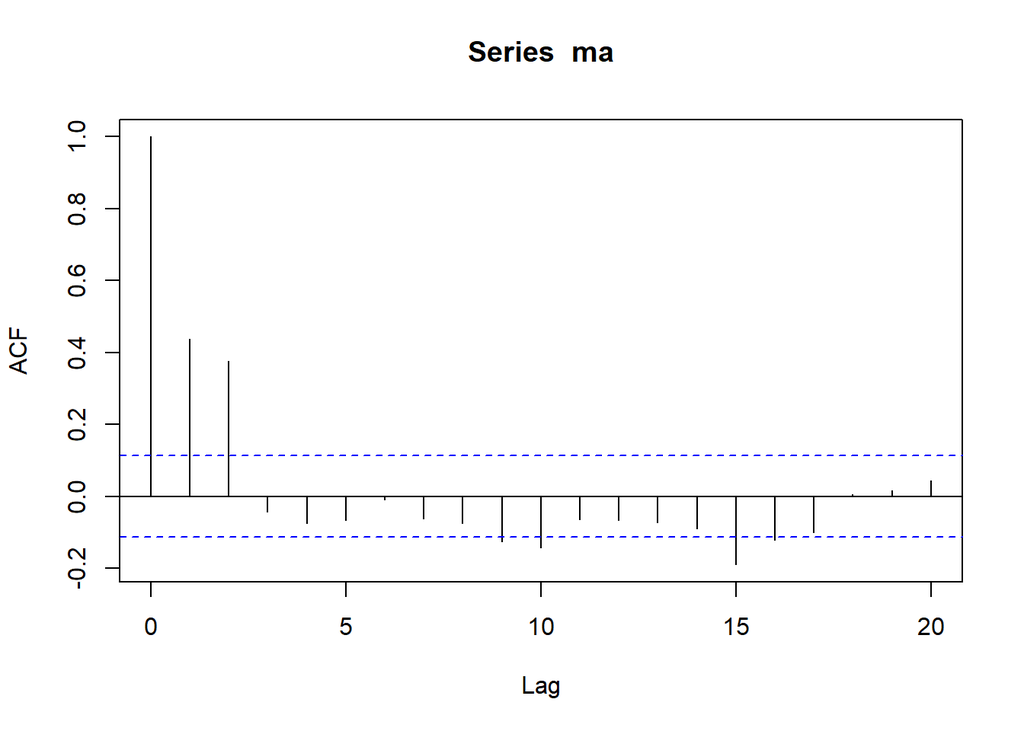

```r
acf(ma,lag.max = 20)
```

Berdasarkan plot AFC tersebut, terlihat bahwa plot ACF *cuts off* di lag kedua.

### Plot PACF

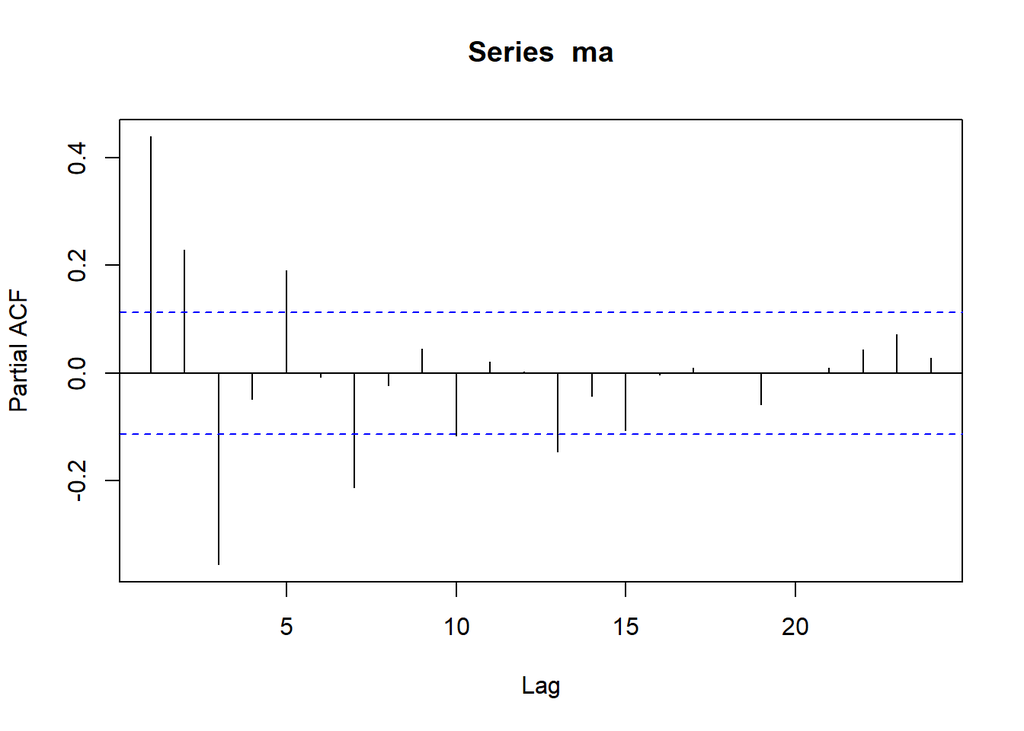

```r
pacf(ma)
```

Berdasarkan plot PACF tersebut, terlihat bahwa plot PACF cenderung *tails off* dan membentuk gelombang sinus.

### Plot EACF

```r
TSA::eacf(ma)
```

```
## AR/MA
##   0 1 2 3 4 5 6 7 8 9 10 11 12 13
## 0 x x o o o o o o x x o  o  o  o
## 1 x x x o o o o o o o o  o  o  o
## 2 x x x x o o o o o x o  o  o  o
## 3 x x o x x o o o o o o  o  o  o
## 4 x x o x o o o o o o o  o  o  o
## 5 o x x x x o x o o o o  o  o  o
## 6 o x x x o o x o o o o  o  o  o
## 7 o x x x x o x o x o o  o  o  o
```

Berdasarkan pola segitiga nol pada plot EACF, terlihat bahwa segitiga nol berada pada ordo AR(0) dan ordo MA(2)

## Buatlah scatterplot antara $Y_t$ dengan $Y_{t-1}$, $Y_t$ dengan $Y_{t-2}$, dan $Y_t$ dengan $Y_{t-3}$

### Korelasi antara $Y_t$ dengan $Y_{t-1}$

```r
#Yt
yt1_ma2 <- ma2[-1]
yt1_ma2
```

```
##   [1] -0.850804055  0.499757168 -1.282264464 -0.547840914 -1.575171808
##   [6] -2.048969551 -2.635133956 -1.571118561 -1.790433630 -1.717066338
##  [11] -0.556133552  0.072669291  1.929914004  1.622290675  1.146337528
##  [16]  0.859824636  1.116855057 -0.191069929 -0.512269221 -1.334764260
##  [21] -0.621694643 -0.509740435  1.505990240  1.457148632 -0.220387312
##  [26]  1.708900173 -1.593188538 -0.457951490 -1.074571780 -1.424819544
##  [31]  0.444904719  1.162710619  0.801165189  1.235879033  0.632147482
##  [36]  1.096573788  1.407632885 -1.045479149 -0.070897014 -1.294572191
##  [41] -1.413649335  0.298450337 -1.586486923 -1.553027865 -1.772460310
##  [46]  0.126243449 -0.527127135 -0.067794069 -0.241172973  1.021325829
##  [51] -0.175471645  1.150838818 -0.752948351 -1.013927783 -0.753370742
##  [56]  0.148780792  0.501991662  1.015190456 -1.300195853  1.166044768
##  [61] -0.305120098  0.674591499  0.415204624 -1.047739572 -0.260909831
##  [66] -0.986268839  0.038637905 -0.382428179 -0.406402097  0.773056227
##  [71]  0.002205856  0.754852936 -0.786248286 -0.545091953 -0.616142986
```

[output cut: 45 more lines]

```r
#Yt-1
yt_1_ma2 <- ma2[-300]
yt_1_ma2
```

```
##   [1] -1.071082769 -0.850804055  0.499757168 -1.282264464 -0.547840914
##   [6] -1.575171808 -2.048969551 -2.635133956 -1.571118561 -1.790433630
##  [11] -1.717066338 -0.556133552  0.072669291  1.929914004  1.622290675
##  [16]  1.146337528  0.859824636  1.116855057 -0.191069929 -0.512269221
##  [21] -1.334764260 -0.621694643 -0.509740435  1.505990240  1.457148632
##  [26] -0.220387312  1.708900173 -1.593188538 -0.457951490 -1.074571780
##  [31] -1.424819544  0.444904719  1.162710619  0.801165189  1.235879033
##  [36]  0.632147482  1.096573788  1.407632885 -1.045479149 -0.070897014
##  [41] -1.294572191 -1.413649335  0.298450337 -1.586486923 -1.553027865
##  [46] -1.772460310  0.126243449 -0.527127135 -0.067794069 -0.241172973
##  [51]  1.021325829 -0.175471645  1.150838818 -0.752948351 -1.013927783
##  [56] -0.753370742  0.148780792  0.501991662  1.015190456 -1.300195853
##  [61]  1.166044768 -0.305120098  0.674591499  0.415204624 -1.047739572
##  [66] -0.260909831 -0.986268839  0.038637905 -0.382428179 -0.406402097
##  [71]  0.773056227  0.002205856  0.754852936 -0.786248286 -0.545091953
```

[output cut: 45 more lines]

### Korelasi antara $Y_t$ dengan $Y_{t-2}$

```r
#Yt
yt2_ma2 <- ma2[-c(1,2)]
yt2_ma2
```

```
##   [1]  0.499757168 -1.282264464 -0.547840914 -1.575171808 -2.048969551
##   [6] -2.635133956 -1.571118561 -1.790433630 -1.717066338 -0.556133552
##  [11]  0.072669291  1.929914004  1.622290675  1.146337528  0.859824636
##  [16]  1.116855057 -0.191069929 -0.512269221 -1.334764260 -0.621694643
##  [21] -0.509740435  1.505990240  1.457148632 -0.220387312  1.708900173
##  [26] -1.593188538 -0.457951490 -1.074571780 -1.424819544  0.444904719
##  [31]  1.162710619  0.801165189  1.235879033  0.632147482  1.096573788
##  [36]  1.407632885 -1.045479149 -0.070897014 -1.294572191 -1.413649335
##  [41]  0.298450337 -1.586486923 -1.553027865 -1.772460310  0.126243449
##  [46] -0.527127135 -0.067794069 -0.241172973  1.021325829 -0.175471645
##  [51]  1.150838818 -0.752948351 -1.013927783 -0.753370742  0.148780792
##  [56]  0.501991662  1.015190456 -1.300195853  1.166044768 -0.305120098
##  [61]  0.674591499  0.415204624 -1.047739572 -0.260909831 -0.986268839
##  [66]  0.038637905 -0.382428179 -0.406402097  0.773056227  0.002205856
##  [71]  0.754852936 -0.786248286 -0.545091953 -0.616142986  0.563288411
```

[output cut: 45 more lines]

```r
#Yt-2
yt_2_ma2 <- ma2[-c(300,299)]
yt_2_ma2
```

```
##   [1] -1.071082769 -0.850804055  0.499757168 -1.282264464 -0.547840914
##   [6] -1.575171808 -2.048969551 -2.635133956 -1.571118561 -1.790433630
##  [11] -1.717066338 -0.556133552  0.072669291  1.929914004  1.622290675
##  [16]  1.146337528  0.859824636  1.116855057 -0.191069929 -0.512269221
##  [21] -1.334764260 -0.621694643 -0.509740435  1.505990240  1.457148632
##  [26] -0.220387312  1.708900173 -1.593188538 -0.457951490 -1.074571780
##  [31] -1.424819544  0.444904719  1.162710619  0.801165189  1.235879033
##  [36]  0.632147482  1.096573788  1.407632885 -1.045479149 -0.070897014
##  [41] -1.294572191 -1.413649335  0.298450337 -1.586486923 -1.553027865
##  [46] -1.772460310  0.126243449 -0.527127135 -0.067794069 -0.241172973
##  [51]  1.021325829 -0.175471645  1.150838818 -0.752948351 -1.013927783
##  [56] -0.753370742  0.148780792  0.501991662  1.015190456 -1.300195853
##  [61]  1.166044768 -0.305120098  0.674591499  0.415204624 -1.047739572
##  [66] -0.260909831 -0.986268839  0.038637905 -0.382428179 -0.406402097
##  [71]  0.773056227  0.002205856  0.754852936 -0.786248286 -0.545091953
```

[output cut: 45 more lines]

### Korelasi antara $Y_t$ dengan $Y_{t-3}$

```r
#Yt
yt3_ma2 <- ma2[-c(1,2,3)]
yt3_ma2
```

```
##   [1] -1.282264464 -0.547840914 -1.575171808 -2.048969551 -2.635133956
##   [6] -1.571118561 -1.790433630 -1.717066338 -0.556133552  0.072669291
##  [11]  1.929914004  1.622290675  1.146337528  0.859824636  1.116855057
##  [16] -0.191069929 -0.512269221 -1.334764260 -0.621694643 -0.509740435
##  [21]  1.505990240  1.457148632 -0.220387312  1.708900173 -1.593188538
##  [26] -0.457951490 -1.074571780 -1.424819544  0.444904719  1.162710619
##  [31]  0.801165189  1.235879033  0.632147482  1.096573788  1.407632885
##  [36] -1.045479149 -0.070897014 -1.294572191 -1.413649335  0.298450337
##  [41] -1.586486923 -1.553027865 -1.772460310  0.126243449 -0.527127135
##  [46] -0.067794069 -0.241172973  1.021325829 -0.175471645  1.150838818
##  [51] -0.752948351 -1.013927783 -0.753370742  0.148780792  0.501991662
##  [56]  1.015190456 -1.300195853  1.166044768 -0.305120098  0.674591499
##  [61]  0.415204624 -1.047739572 -0.260909831 -0.986268839  0.038637905
##  [66] -0.382428179 -0.406402097  0.773056227  0.002205856  0.754852936
##  [71] -0.786248286 -0.545091953 -0.616142986  0.563288411  0.524051538
```

[output cut: 45 more lines]

```r
#Yt-3
yt_3_ma2 <- ma2[-c(300,299,298)]
yt_3_ma2
```

```
##   [1] -1.071082769 -0.850804055  0.499757168 -1.282264464 -0.547840914
##   [6] -1.575171808 -2.048969551 -2.635133956 -1.571118561 -1.790433630
##  [11] -1.717066338 -0.556133552  0.072669291  1.929914004  1.622290675
##  [16]  1.146337528  0.859824636  1.116855057 -0.191069929 -0.512269221
##  [21] -1.334764260 -0.621694643 -0.509740435  1.505990240  1.457148632
##  [26] -0.220387312  1.708900173 -1.593188538 -0.457951490 -1.074571780
##  [31] -1.424819544  0.444904719  1.162710619  0.801165189  1.235879033
##  [36]  0.632147482  1.096573788  1.407632885 -1.045479149 -0.070897014
##  [41] -1.294572191 -1.413649335  0.298450337 -1.586486923 -1.553027865
##  [46] -1.772460310  0.126243449 -0.527127135 -0.067794069 -0.241172973
##  [51]  1.021325829 -0.175471645  1.150838818 -0.752948351 -1.013927783
##  [56] -0.753370742  0.148780792  0.501991662  1.015190456 -1.300195853
##  [61]  1.166044768 -0.305120098  0.674591499  0.415204624 -1.047739572
##  [66] -0.260909831 -0.986268839  0.038637905 -0.382428179 -0.406402097
##  [71]  0.773056227  0.002205856  0.754852936 -0.786248286 -0.545091953
```

[output cut: 45 more lines]

### Plot

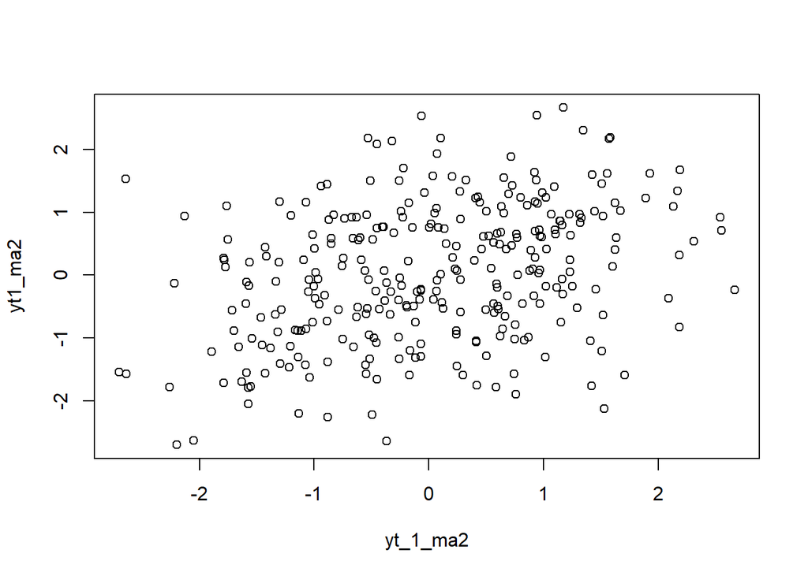

```r
plot(y=yt1_ma2,x=yt_1_ma2)
```

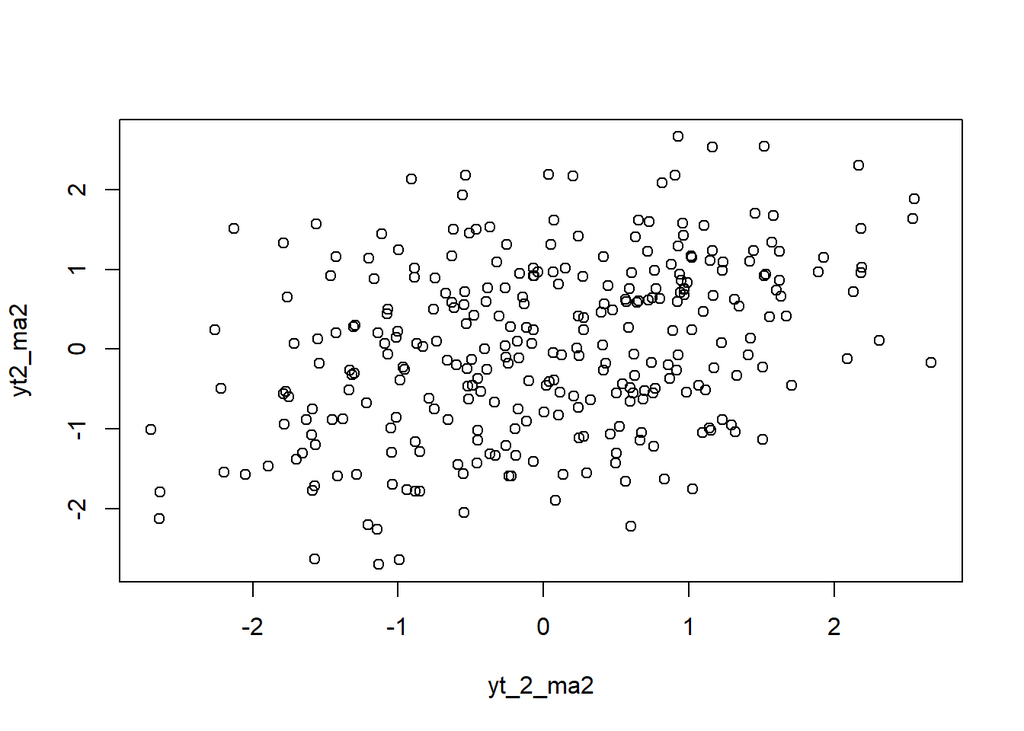

```r
plot(y=yt2_ma2,x=yt_2_ma2)
```

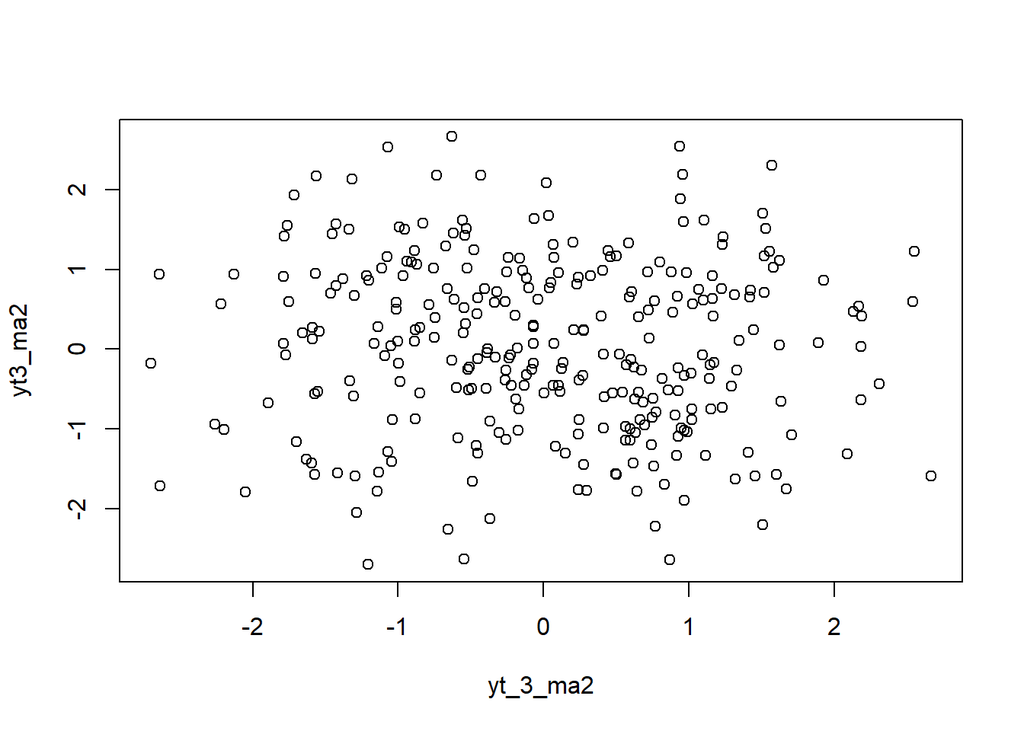

```r
plot(y=yt3_ma2,x=yt_3_ma2)
```

```r
cor(yt1_ma2,yt_1_ma2)
```

```
## [1] 0.3369231
```

```r
cor(yt2_ma2,yt_2_ma2)
```

```
## [1] 0.3545613
```

```r
cor(yt3_ma2,yt_3_ma2)
```

```
## [1] -0.06551178
```

# Bangkitkan model AR(2) dengan theta1= 0.5 dan theta2 = 0.2 sebanyak 300 data(Manual dan dengan arima.sim)

# Proses AR (2)

Proses AR dapat dituliskan sebagai berikut:

$$y_{t} = c + e_t + \phi_{1}Y_{t-1} +
\phi_{2}Y_{t-2} + \dots + \phi_{q}Y_{t-q} = c+{e_t+\sum_{i=1}^p
\phi_iY_{t-i}}$$
Terlihat bahwa $Y_t$ berperan penting dalam pembangkitan proses AR.

## Pembangkitan Proses AR

Nilai-nilai selanjutnya dapat dicari melalui *loop*. Bentuk loop dapat dilihat dari rumus AR(2) yang hendak dibangkitkan:

$$Y_t = e_t+0.5Y_{t-1}+0.2Y_{t-2}$$

```r
set.seed(1029)
n<-length(data)
n
```

```
## [1] 300
```

```r
ar <- c(2:n)
for (i in 3:n) {ar[i]<-data[i]+0.5*ar[i-1]+0.2*ar[i-2]}
ar
```

```
##   [1]  2.000000000  3.000000000  3.062963849  1.079532353  0.668835173
##   [6]  0.529252493  0.516984767  0.352137685  2.881908211  0.520846489
##  [11]  0.347527036 -0.356117264  0.160166530  1.320376096  0.419474583
##  [16]  2.574751504  3.172721558  0.469517274 -1.542268687  0.300518550
##  [21] -0.880465587  1.524933632  1.935670452  1.853164335  1.017135744
##  [26]  2.697969775  1.546516941  0.617723257  0.369099251 -0.570148624
##  [31] -0.097317623 -0.947742559  0.111489694 -0.087989017 -1.735330386
##  [36]  0.140814552 -0.413462762 -0.885340171 -0.193836282 -1.017275686
##  [41]  0.093066410  0.106800241 -0.264630009 -0.192506575  1.703833071
##  [46]  0.574685769  1.449927439 -0.313927718  0.874833489 -0.677553099
##  [51]  0.427310419 -1.841102022  0.464207785 -0.736394251 -1.011735758
##  [56] -0.509946806  0.051296889 -0.012775371  0.846980538  0.643552994
##  [61]  0.974753891 -0.495551833  2.170344423  1.254287221  0.809978483
##  [66]  1.556355149  1.349461449  0.581077404  1.357620669  0.771225779
##  [71]  1.288626908  0.521106904  0.091448721  0.507939862 -0.137103875
```

[output cut: 45 more lines]

Selain menggunakan cara di atas, pembangkitan proses AR dapat dilakukan dengan fungsi `arima.sim()` sebagai berikut.

```r
set.seed(1029)
ar2 <- arima.sim(list(order=c(2,0,0), ar=(c(0.5 , 0.2))), n=300)
ar2
```

```
## Time Series:
## Start = 1
## End = 300
## Frequency = 1
##   [1]  1.215942714  1.448976036 -0.567634760  1.760737453 -0.607063821
##   [6] -0.912629447 -0.443457900 -1.306035202 -0.016654070  1.144222717
##  [11]  0.369409949  0.880922714  1.079163908  1.305988143  1.701478743
##  [16] -0.620735893  0.152508811 -0.351893632 -1.511042651  0.201189839
##  [21] -1.379577932 -2.347647069 -1.836182410 -0.087942212 -1.226340112
##  [26] -1.152306602 -0.364895540  0.738735288 -0.613656330  0.664789030
##  [31] -0.326806238 -1.324107384 -0.641439161  0.305046666  0.118406607
##  [36]  0.563382016 -1.228593939  1.012109081  0.270103557  0.099920184
##  [41]  0.608346110 -0.782796557 -0.390476612 -0.625595245 -0.170287456
##  [46] -0.516654575 -0.708593450  0.665747135 -0.006263974  0.289813051
##  [51] -0.588061489 -0.584351366 -0.447588542  0.446714031  0.365619752
```

[output cut: 49 more lines]

## Buatlah Plot time series, Plot ACF, plot PACF, dan Plot EACF. Identifikasi apakah data tersebut stasioner

### Plot Time Series

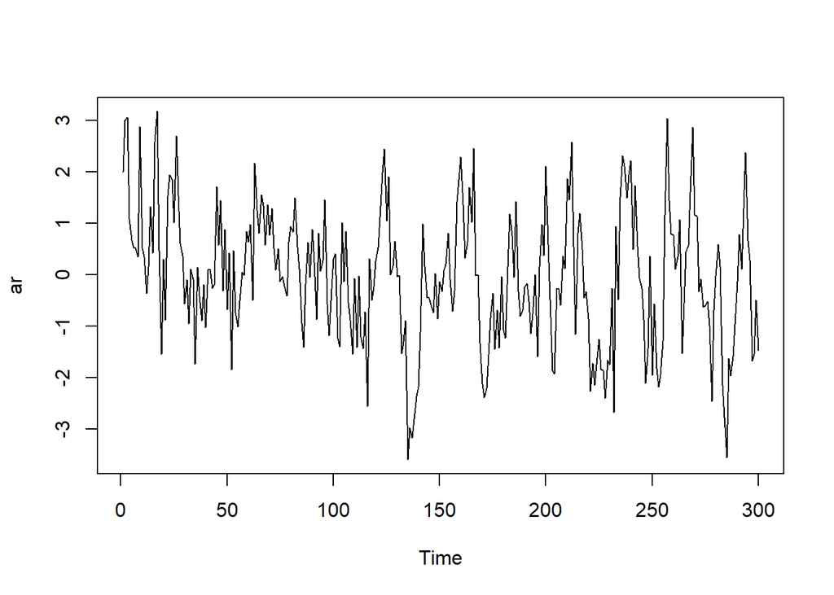

```r
ts.plot(ar)
```

Berdasarkan plot time series tersebut terlihat bahwa data cenderung stasioner pada rataan

### Plot ACF

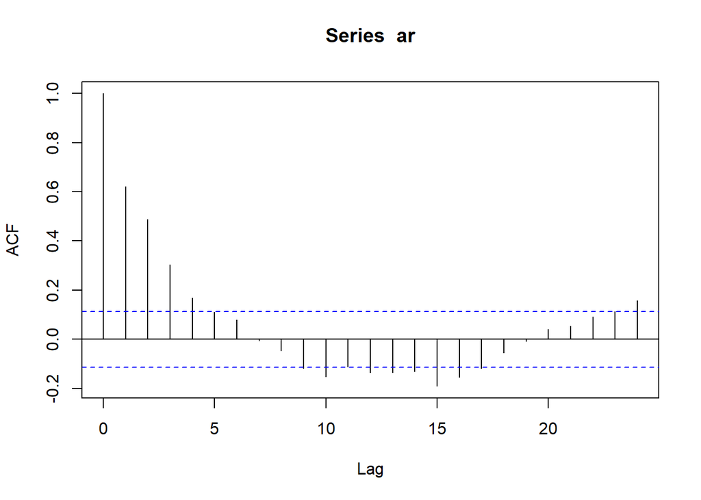

```r
acf(ar)
```

Berdasarkan plot ACF tersebut terlihat bahwa plot ACF cenderung *tails off* dan cenderung membentuk pola grafik sinus

### Plot PACF

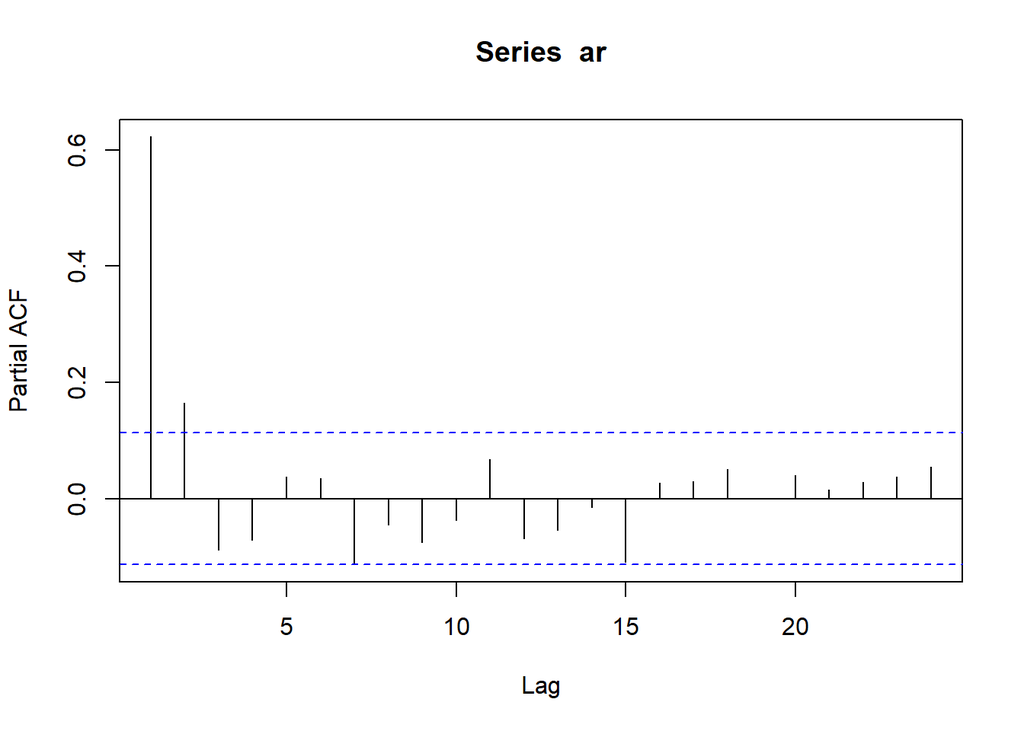

```r
pacf(ar)
```

### Plot EACF

```r
TSA::eacf(ar2)
```

```
## AR/MA
##   0 1 2 3 4 5 6 7 8 9 10 11 12 13
## 0 x x x x o o o o o o o  o  o  o
## 1 x o o o o o o o o o o  o  o  o
## 2 o x o o o o o o o o o  o  o  o
## 3 x x o o o o o o o o o  o  o  o
## 4 o x o o o o o o o o o  o  o  o
## 5 x x x o o o o o o o o  o  o  o
## 6 x x x o o o o o o o o  o  o  o
## 7 x x x o x o x o o o o  o  o  o
```

## Buatlah scatterplot antara $Y_t$ dengan $Y_{t-1}$, $Y_t$ dengan $Y_{t-2}$, dan $Y_t$ dengan $Y_{t-3}$

### Korelasi antara $Y_t$ dengan $Y_{t-1}$

```r
#Yt
yt_ar <- ar[-1]
yt_ar
```

```
##   [1]  3.000000000  3.062963849  1.079532353  0.668835173  0.529252493
##   [6]  0.516984767  0.352137685  2.881908211  0.520846489  0.347527036
##  [11] -0.356117264  0.160166530  1.320376096  0.419474583  2.574751504
##  [16]  3.172721558  0.469517274 -1.542268687  0.300518550 -0.880465587
##  [21]  1.524933632  1.935670452  1.853164335  1.017135744  2.697969775
##  [26]  1.546516941  0.617723257  0.369099251 -0.570148624 -0.097317623
##  [31] -0.947742559  0.111489694 -0.087989017 -1.735330386  0.140814552
##  [36] -0.413462762 -0.885340171 -0.193836282 -1.017275686  0.093066410
##  [41]  0.106800241 -0.264630009 -0.192506575  1.703833071  0.574685769
##  [46]  1.449927439 -0.313927718  0.874833489 -0.677553099  0.427310419
##  [51] -1.841102022  0.464207785 -0.736394251 -1.011735758 -0.509946806
##  [56]  0.051296889 -0.012775371  0.846980538  0.643552994  0.974753891
##  [61] -0.495551833  2.170344423  1.254287221  0.809978483  1.556355149
##  [66]  1.349461449  0.581077404  1.357620669  0.771225779  1.288626908
##  [71]  0.521106904  0.091448721  0.507939862 -0.137103875 -0.040570810
```

[output cut: 45 more lines]

```r
#Yt-1
yt_1_ar <- ar[-300]
yt_1_ar
```

```
##   [1]  2.000000000  3.000000000  3.062963849  1.079532353  0.668835173
##   [6]  0.529252493  0.516984767  0.352137685  2.881908211  0.520846489
##  [11]  0.347527036 -0.356117264  0.160166530  1.320376096  0.419474583
##  [16]  2.574751504  3.172721558  0.469517274 -1.542268687  0.300518550
##  [21] -0.880465587  1.524933632  1.935670452  1.853164335  1.017135744
##  [26]  2.697969775  1.546516941  0.617723257  0.369099251 -0.570148624
##  [31] -0.097317623 -0.947742559  0.111489694 -0.087989017 -1.735330386
##  [36]  0.140814552 -0.413462762 -0.885340171 -0.193836282 -1.017275686
##  [41]  0.093066410  0.106800241 -0.264630009 -0.192506575  1.703833071
##  [46]  0.574685769  1.449927439 -0.313927718  0.874833489 -0.677553099
##  [51]  0.427310419 -1.841102022  0.464207785 -0.736394251 -1.011735758
##  [56] -0.509946806  0.051296889 -0.012775371  0.846980538  0.643552994
##  [61]  0.974753891 -0.495551833  2.170344423  1.254287221  0.809978483
##  [66]  1.556355149  1.349461449  0.581077404  1.357620669  0.771225779
##  [71]  1.288626908  0.521106904  0.091448721  0.507939862 -0.137103875
```

[output cut: 45 more lines]

### Korelasi antara $Y_t$ dengan $Y_{t-2}$

```r
#Yt
yt_ar2 <- ar[-c(1,2)]
yt_ar2
```

```
##   [1]  3.062963849  1.079532353  0.668835173  0.529252493  0.516984767
##   [6]  0.352137685  2.881908211  0.520846489  0.347527036 -0.356117264
##  [11]  0.160166530  1.320376096  0.419474583  2.574751504  3.172721558
##  [16]  0.469517274 -1.542268687  0.300518550 -0.880465587  1.524933632
##  [21]  1.935670452  1.853164335  1.017135744  2.697969775  1.546516941
##  [26]  0.617723257  0.369099251 -0.570148624 -0.097317623 -0.947742559
##  [31]  0.111489694 -0.087989017 -1.735330386  0.140814552 -0.413462762
##  [36] -0.885340171 -0.193836282 -1.017275686  0.093066410  0.106800241
##  [41] -0.264630009 -0.192506575  1.703833071  0.574685769  1.449927439
##  [46] -0.313927718  0.874833489 -0.677553099  0.427310419 -1.841102022
##  [51]  0.464207785 -0.736394251 -1.011735758 -0.509946806  0.051296889
##  [56] -0.012775371  0.846980538  0.643552994  0.974753891 -0.495551833
##  [61]  2.170344423  1.254287221  0.809978483  1.556355149  1.349461449
##  [66]  0.581077404  1.357620669  0.771225779  1.288626908  0.521106904
##  [71]  0.091448721  0.507939862 -0.137103875 -0.040570810 -0.218833277
```

[output cut: 45 more lines]

```r
#Yt-2
yt_2_ar <- ar[-c(299,300)]
yt_2_ar
```

```
##   [1]  2.000000000  3.000000000  3.062963849  1.079532353  0.668835173
##   [6]  0.529252493  0.516984767  0.352137685  2.881908211  0.520846489
##  [11]  0.347527036 -0.356117264  0.160166530  1.320376096  0.419474583
##  [16]  2.574751504  3.172721558  0.469517274 -1.542268687  0.300518550
##  [21] -0.880465587  1.524933632  1.935670452  1.853164335  1.017135744
##  [26]  2.697969775  1.546516941  0.617723257  0.369099251 -0.570148624
##  [31] -0.097317623 -0.947742559  0.111489694 -0.087989017 -1.735330386
##  [36]  0.140814552 -0.413462762 -0.885340171 -0.193836282 -1.017275686
##  [41]  0.093066410  0.106800241 -0.264630009 -0.192506575  1.703833071
##  [46]  0.574685769  1.449927439 -0.313927718  0.874833489 -0.677553099
##  [51]  0.427310419 -1.841102022  0.464207785 -0.736394251 -1.011735758
##  [56] -0.509946806  0.051296889 -0.012775371  0.846980538  0.643552994
##  [61]  0.974753891 -0.495551833  2.170344423  1.254287221  0.809978483
##  [66]  1.556355149  1.349461449  0.581077404  1.357620669  0.771225779
##  [71]  1.288626908  0.521106904  0.091448721  0.507939862 -0.137103875
```

[output cut: 45 more lines]

### Korelasi antara $Y_t$ dengan $Y_{t-3}$

```r
#Yt
yt_ar3 <- ar[-c(1,2,3)]
yt_ar3
```

```
##   [1]  1.079532353  0.668835173  0.529252493  0.516984767  0.352137685
##   [6]  2.881908211  0.520846489  0.347527036 -0.356117264  0.160166530
##  [11]  1.320376096  0.419474583  2.574751504  3.172721558  0.469517274
##  [16] -1.542268687  0.300518550 -0.880465587  1.524933632  1.935670452
##  [21]  1.853164335  1.017135744  2.697969775  1.546516941  0.617723257
##  [26]  0.369099251 -0.570148624 -0.097317623 -0.947742559  0.111489694
##  [31] -0.087989017 -1.735330386  0.140814552 -0.413462762 -0.885340171
##  [36] -0.193836282 -1.017275686  0.093066410  0.106800241 -0.264630009
##  [41] -0.192506575  1.703833071  0.574685769  1.449927439 -0.313927718
##  [46]  0.874833489 -0.677553099  0.427310419 -1.841102022  0.464207785
##  [51] -0.736394251 -1.011735758 -0.509946806  0.051296889 -0.012775371
##  [56]  0.846980538  0.643552994  0.974753891 -0.495551833  2.170344423
##  [61]  1.254287221  0.809978483  1.556355149  1.349461449  0.581077404
##  [66]  1.357620669  0.771225779  1.288626908  0.521106904  0.091448721
##  [71]  0.507939862 -0.137103875 -0.040570810 -0.218833277 -0.406653919
```

[output cut: 45 more lines]

```r
#Yt-3
yt_3_ar <- ar[-c(298,299,300)]
yt_3_ar
```

```
##   [1]  2.000000000  3.000000000  3.062963849  1.079532353  0.668835173
##   [6]  0.529252493  0.516984767  0.352137685  2.881908211  0.520846489
##  [11]  0.347527036 -0.356117264  0.160166530  1.320376096  0.419474583
##  [16]  2.574751504  3.172721558  0.469517274 -1.542268687  0.300518550
##  [21] -0.880465587  1.524933632  1.935670452  1.853164335  1.017135744
##  [26]  2.697969775  1.546516941  0.617723257  0.369099251 -0.570148624
##  [31] -0.097317623 -0.947742559  0.111489694 -0.087989017 -1.735330386
##  [36]  0.140814552 -0.413462762 -0.885340171 -0.193836282 -1.017275686
##  [41]  0.093066410  0.106800241 -0.264630009 -0.192506575  1.703833071
##  [46]  0.574685769  1.449927439 -0.313927718  0.874833489 -0.677553099
##  [51]  0.427310419 -1.841102022  0.464207785 -0.736394251 -1.011735758
##  [56] -0.509946806  0.051296889 -0.012775371  0.846980538  0.643552994
##  [61]  0.974753891 -0.495551833  2.170344423  1.254287221  0.809978483
##  [66]  1.556355149  1.349461449  0.581077404  1.357620669  0.771225779
##  [71]  1.288626908  0.521106904  0.091448721  0.507939862 -0.137103875
```

[output cut: 45 more lines]

### Plot

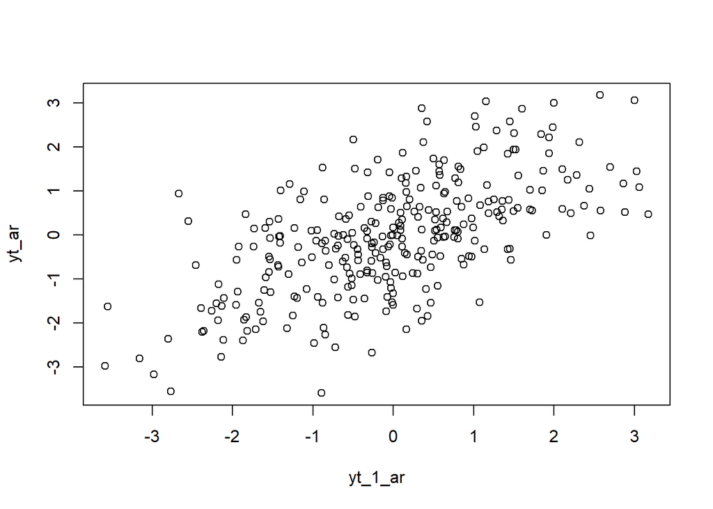

```r
plot(y=yt_ar,x=yt_1_ar)
```

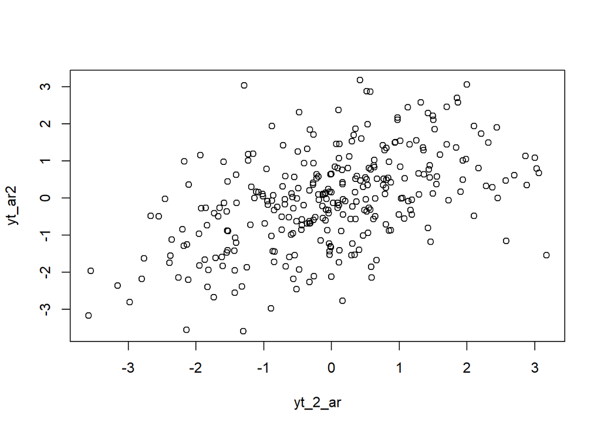

```r
plot(y=yt_ar2,x=yt_2_ar)
```

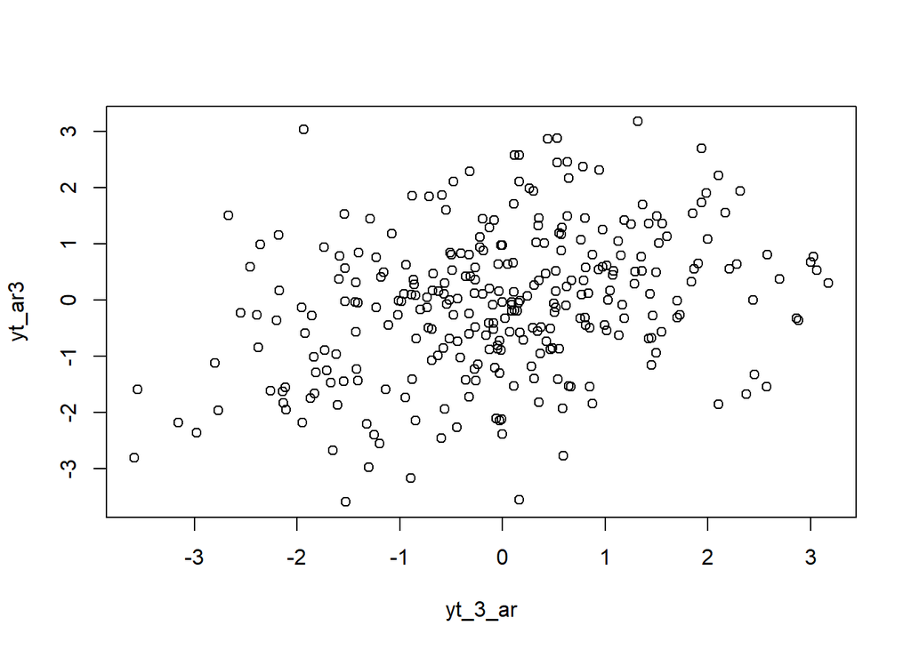

```r
plot(y=yt_ar3,x=yt_3_ar)
```

Berdasarkan scatterplot tersebut, terlihat bahwa terdapat hubungan positif yang kuat antara $Y_t$ dengan $Y_{t-1}$.Berdasarkan scatterplot tersebut, terlihat bahwa terdapat hubungan positif yang sedang antara $Y_t$ dengan $Y_{t-2}$. Berdasarkan scatterplot tersebut, terlihat bahwa terdapat hubungan positif yang lemah antara $Y_t$ dengan $Y_{t-3}$.Hal ini sesuai dengan teori yang ada.

```r
cor(yt_ar,yt_1_ar)
```

```
## [1] 0.6263705
```

```r
cor(yt_ar2,yt_2_ar)
```

```
## [1] 0.4963523
```

```r
cor(yt_ar3,yt_3_ar)
```

```
## [1] 0.3127067
```

# Fungsi pembangkitan ARMA

Setelah mengetahui cara membangkitkan data berpola AR, MA, dan ARMA sederhana, bagaimana cara melakukan pembangkitan data berpola tersebut yang lebih kompleks? Apakah dapat dibuat suatu fungsi yang fleksibel yang memungkinan pembangkitan dengan berapapun jumlah koefisien?

Pertama, lihat kembali bentuk umum data berpola ARMA.

$$y_{t} = c + \sum_{i=1}^p \phi_{i}y_{t-i} + \sum_{j=1}^q e_{t-j}+ e_{t}$$

Komponen $c$ dan $e_{t}$ cukup mudah untuk dibuat dan dicari. Bagaimana untuk komponen AR dan MA? Bayangkan ada koefisien dan data sebagai berikut:

$$\begin{aligned}
\begin{bmatrix}
\phi_1 \ \phi_2 \
\end{bmatrix}&=
\begin{bmatrix}
0.5 \ 0.2
\end{bmatrix}
\\
\begin{bmatrix}
y_{t-1} \ y_{t-2}
\end{bmatrix}&=
\begin{bmatrix}
1 \ 2
\end{bmatrix}
\end{aligned}$$

Maka dari itu,

$$\begin{aligned}
\begin{bmatrix}
\phi_1 \ \phi_2 \
\end{bmatrix}
\begin{bmatrix}
y_{t-1} \\ y_{t-2}
\end{bmatrix} &= \phi_1 \ y_{t-1}+\phi_2 \ y_{t-2}
\begin{bmatrix}
0.5 \ 0.2
\end{bmatrix}
\begin{bmatrix}
1 \\ 2
\end{bmatrix} & = 0.5 \cdot1+0.2 \cdot 2= 0.9
\end{aligned}$$

Jika koefisien dan *white noise*/nilai deret waktu sebelumnya dapat diekstrak dalam bentuk vektor, dapat dilakukan perkalian matriks untuk mencari nilai bagian AR dan MA:

# Bangkitkan model ARIMA(2,2) dengan theta1= 0.4 dan theta2 = 0.6, dots1=0.5 dan dots2=0.2 sebanyak 300 data(Manual dan dengan arima.sim)

```r
set.seed(1029)
coefs <- c(0.5, 0.2)
e <- c(1, 2)

coefs %*% e
```

```
##      [,1]
## [1,]  0.9
```

Atau, dapat dilakukan perkalian *elementwise* yang dijumlahkan:

```r
coefs * e
```

```
## [1] 0.5 0.4
```

```r
sum(coefs * e)
```

```
## [1] 0.9
```

Dari prinsip ini, dapat dibuat fungsi umum untuk membangkitkan data ARMA. Input dari fungsi adalah jumlah data yang hendak dibangkitkan, koefisien MA, dan koefisien AR

```r
arma.sim <- function(n, macoef, arcoef){
  manum <- length(macoef)
  arnum <- length(arcoef)
  stopifnot(manum < n & arnum < n)

  data <- rnorm(n, sd = 0.5)
  init <- max(manum, arnum)

  arma <- data[1:init]
  for(i in {init+1}:n){
   mastart <- i - manum
   maend <- i-1
   arstart <- i - arnum
   arend <- i-1
   arma[i] <- sum(arcoef * arma[arstart:arend]) + sum(macoef * data[mastart:maend])  + data[i]
   }
  return(arma)
}
```

Terlihat bahwa komponen $\sum_{i=1}^q y_{t-1}$ disimulasikan melalui `sum(arcoef * arma[arstart:arend])`. Jadi, koefisien dikalikan dengan data $y$ dari $t-q$ di mana q adalah jumlah koefisien AR, sampai data $t-1$. Lalu komponen $\sum_{j=1}^q e_{t-j}$ disimulasikan melalui `sum(macoef * data[mastart:maend])`. Koefisien dikalikan dengan *white noise* $e$ dari $t-p$, p jumlah koefisien MA, sampai $t-1$.

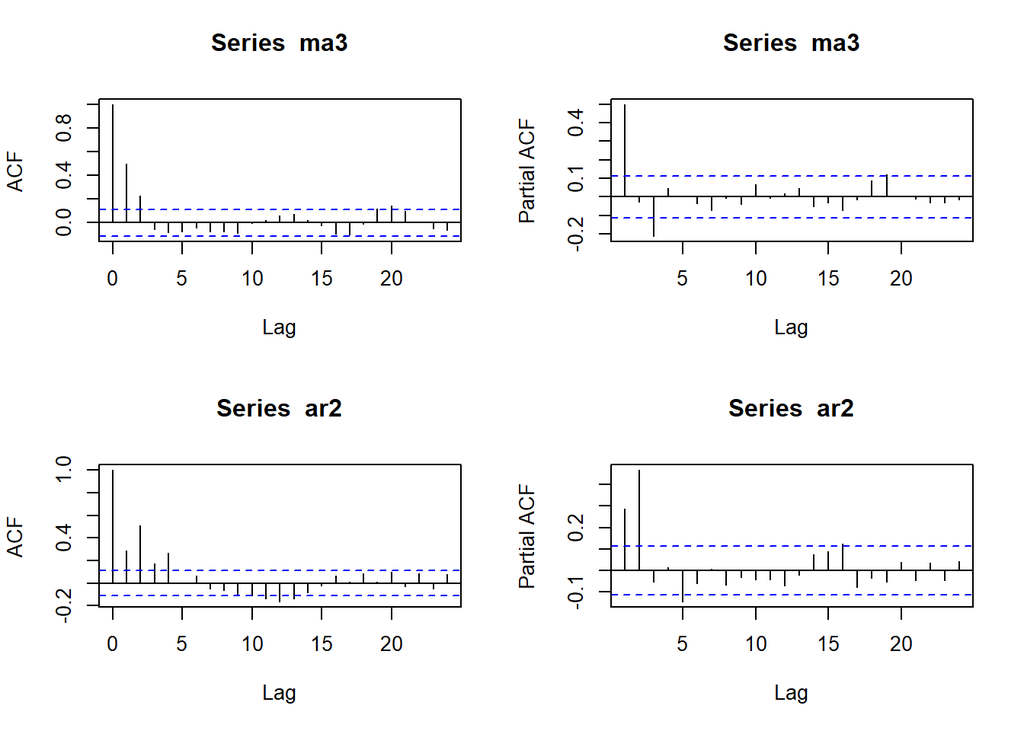

```r
ma3 <- arma.sim(300, c(0.4, 0.6), 0)
ar2 <- arma.sim(300, 0, c(0.5, 0.2))

par(mfrow = c(2, 2))
acf(ma3)
pacf(ma3)
acf(ar2)
pacf(ar2)
```

## ARMA

```r
arma22 <- arma.sim(300, c(0.5, 0.2), c(0.4,0.6))

arma22 |> arima(c(2,0,2))
```

```
##
## Call:
## arima(x = arma22, order = c(2, 0, 2))
##
## Coefficients:
##          ar1     ar2     ma1     ma2  intercept
##       0.5878  0.4076  0.2362  0.5171    11.6274
## s.e.  0.0947  0.0947  0.0901  0.0469     6.0713
##
## sigma^2 estimated as 0.2283:  log likelihood = -207.26,  aic = 426.53
```

```r
set.seed(1029)
n = length(data)
phi1 = 0.5
theta1 = 0.4
phi2 = 0.2
theta2 = 0.6

y.arma=c(1:n)
for (i in 3:n){y.arma[i] = phi1*y.arma[i-1] +  phi2*y.arma[i-2] + theta1*data[i-1]+data[i]+ theta2*data[i-2]+data[i]}
```

Pembangkitan ARMA(p,q) juga dapat dilakukan dengan fungsi `arima.sim` sebagai berikut.

```r
arma22<- arima.sim(list(order=c(2,0,2), ar = c(0.5 ,0.2), ma =c(0.4, 0.6)) , n=300)
arma22
```

```
## Time Series:
## Start = 1
## End = 300
## Frequency = 1
##   [1]  0.74304034  2.40422722 -0.24246686 -0.09833948 -1.17223489 -2.03060488
##   [7] -0.80484470  0.35416729  0.81727989  1.71535244  1.65327968  2.26628412
##  [13]  2.87143088  0.84349311  0.92513572 -0.66330571 -1.56027505 -0.61434833
##  [19] -2.20571610 -2.77875558 -3.60298132 -2.23099833 -2.36322256 -1.69560501
##  [25] -1.56161999 -0.09860517 -0.53709823  0.86256867 -0.42908366 -1.05595588
##  [31] -1.36716541 -0.74599309 -0.14443797  0.79377285 -0.93219702  0.85870083
##  [37] -0.06220909  0.81522712  0.81037637 -0.47950596 -0.33858754 -1.25146380
##  [43] -0.65481150 -0.96012669 -1.01742774  0.07231702 -0.16512118  0.68675575
##  [49] -0.47589465 -0.64568813 -1.03416598 -0.08293220  0.27575224  0.74624311
##  [55] -0.53653035 -0.18566371 -0.42408042  0.67735218  0.53267634  0.33073256
##  [61] -0.82044851 -0.09969010 -0.13956357 -0.16683189 -0.50155894 -0.21522035
```

[output cut: 39 more lines]

## Buatlah Plot time series, Plot ACF, plot PACF, dan Plot EACF. Identifikasi apakah data tersebut stasioner

### Plot Time Series

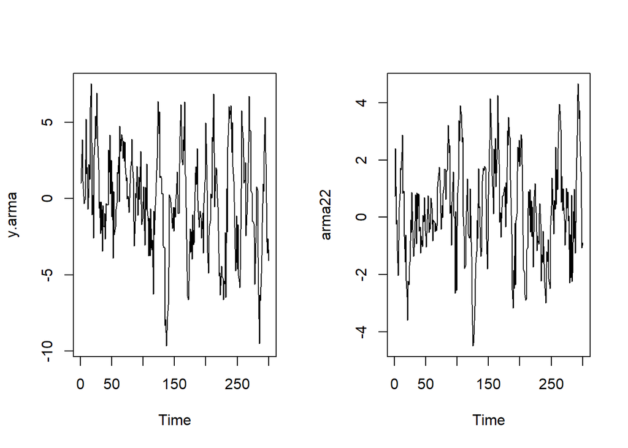

```r
par(mfrow = c(1, 2))
ts.plot(y.arma)
ts.plot(arma22)
```

```r
par(mfrow = c(2, 2))
```

Berdasarkan plot time series tersebut, terlihat bahwa model ARMA(2,2) cenderung stasioner dalam rataan

### Plot ACF

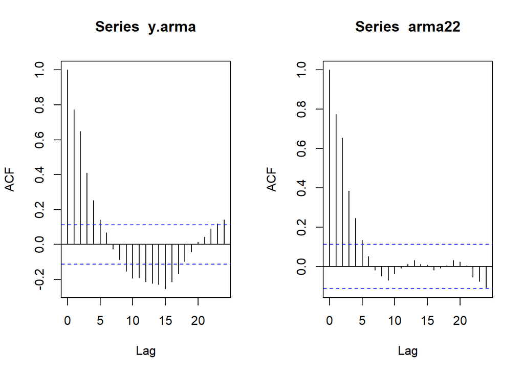

```r
par(mfrow = c(1, 2))
acf(y.arma)
acf(arma22)
```

```r
par(mfrow = c(2, 2))
```

Berdasarkan plot ACF tersebut, terlihat bahwa model ARMA(2,2) hasil simulasi memiliki plot ACF yang *tails off*, sesuai dengan teori yang ada

### Plot PACF

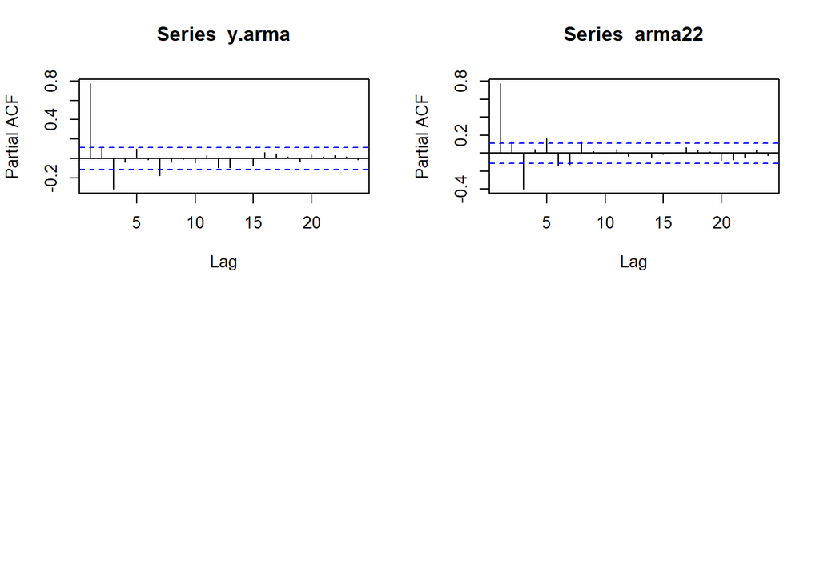

```r
par(mfrow = c(2, 2))
pacf(y.arma)
pacf(arma22)
par(mfrow = c(2, 2))
```

### Plot EACF

```r
TSA::eacf(y.arma)
```

```
## AR/MA
##   0 1 2 3 4 5 6 7 8 9 10 11 12 13
## 0 x x x x x o o o x x x  x  x  x
## 1 x x o o o o o o o o o  o  o  o
## 2 x x o o o x o o o x o  o  o  o
## 3 x x x x o x o o o x o  o  o  o
## 4 x x o o o x o o o o o  o  o  o
## 5 x x o x o x o o o o o  o  o  o
## 6 o x x x o x o o o o o  o  o  o
## 7 x o x x x o o o o o o  o  o  o
```

```r
TSA::eacf(arma22)
```

```
## AR/MA
##   0 1 2 3 4 5 6 7 8 9 10 11 12 13
## 0 x x x x x o o o o o o  o  o  o
## 1 x x o o o o o o o o o  o  o  o
## 2 x x x o o o o o o o o  o  o  o
## 3 o x x o o o o o o o o  o  o  o
## 4 x x x o x o o o o o o  o  o  o
## 5 x x x x x o o o o o o  o  o  o
## 6 x x x o x x x o o o o  o  o  o
## 7 x x x x x x o o o o o  o  o  o
```

## Buatlah scatterplot antara $Y_t$ dengan $Y_{t-1}$, $Y_t$ dengan $Y_{t-2}$, dan $Y_t$ dengan $Y_{t-3}$

### Korelasi antara $Y_t$ dengan $Y_{t-1}$

```r
#Yt
yt_arma <- arma22[-1]
yt_arma
```

```
##   [1]  2.40422722 -0.24246686 -0.09833948 -1.17223489 -2.03060488 -0.80484470
##   [7]  0.35416729  0.81727989  1.71535244  1.65327968  2.26628412  2.87143088
##  [13]  0.84349311  0.92513572 -0.66330571 -1.56027505 -0.61434833 -2.20571610
##  [19] -2.77875558 -3.60298132 -2.23099833 -2.36322256 -1.69560501 -1.56161999
##  [25] -0.09860517 -0.53709823  0.86256867 -0.42908366 -1.05595588 -1.36716541
##  [31] -0.74599309 -0.14443797  0.79377285 -0.93219702  0.85870083 -0.06220909
##  [37]  0.81522712  0.81037637 -0.47950596 -0.33858754 -1.25146380 -0.65481150
##  [43] -0.96012669 -1.01742774  0.07231702 -0.16512118  0.68675575 -0.47589465
##  [49] -0.64568813 -1.03416598 -0.08293220  0.27575224  0.74624311 -0.53653035
##  [55] -0.18566371 -0.42408042  0.67735218  0.53267634  0.33073256 -0.82044851
##  [61] -0.09969010 -0.13956357 -0.16683189 -0.50155894 -0.21522035 -0.46148282
##  [67] -0.31285443  1.06370729  1.44019539  1.56090694  1.75331494  0.85484590
##  [73]  0.15005524 -0.41613044  0.41092792 -0.01938142  0.83582053  1.06944093
##  [79]  1.68738409  1.66670135  0.62841476  1.60858305  1.65586404  2.57582443
##  [85]  3.22003517  2.26048313  2.51739847  0.14052150  0.41076757 -0.96927417
```

[output cut: 35 more lines]

```r
#Yt-1
yt_1_arma <- arma22[-200]
yt_1_arma
```

```
##   [1]  0.74304034  2.40422722 -0.24246686 -0.09833948 -1.17223489 -2.03060488
##   [7] -0.80484470  0.35416729  0.81727989  1.71535244  1.65327968  2.26628412
##  [13]  2.87143088  0.84349311  0.92513572 -0.66330571 -1.56027505 -0.61434833
##  [19] -2.20571610 -2.77875558 -3.60298132 -2.23099833 -2.36322256 -1.69560501
##  [25] -1.56161999 -0.09860517 -0.53709823  0.86256867 -0.42908366 -1.05595588
##  [31] -1.36716541 -0.74599309 -0.14443797  0.79377285 -0.93219702  0.85870083
##  [37] -0.06220909  0.81522712  0.81037637 -0.47950596 -0.33858754 -1.25146380
##  [43] -0.65481150 -0.96012669 -1.01742774  0.07231702 -0.16512118  0.68675575
##  [49] -0.47589465 -0.64568813 -1.03416598 -0.08293220  0.27575224  0.74624311
##  [55] -0.53653035 -0.18566371 -0.42408042  0.67735218  0.53267634  0.33073256
##  [61] -0.82044851 -0.09969010 -0.13956357 -0.16683189 -0.50155894 -0.21522035
##  [67] -0.46148282 -0.31285443  1.06370729  1.44019539  1.56090694  1.75331494
##  [73]  0.85484590  0.15005524 -0.41613044  0.41092792 -0.01938142  0.83582053
##  [79]  1.06944093  1.68738409  1.66670135  0.62841476  1.60858305  1.65586404
##  [85]  2.57582443  3.22003517  2.26048313  2.51739847  0.14052150  0.41076757
```

[output cut: 35 more lines]

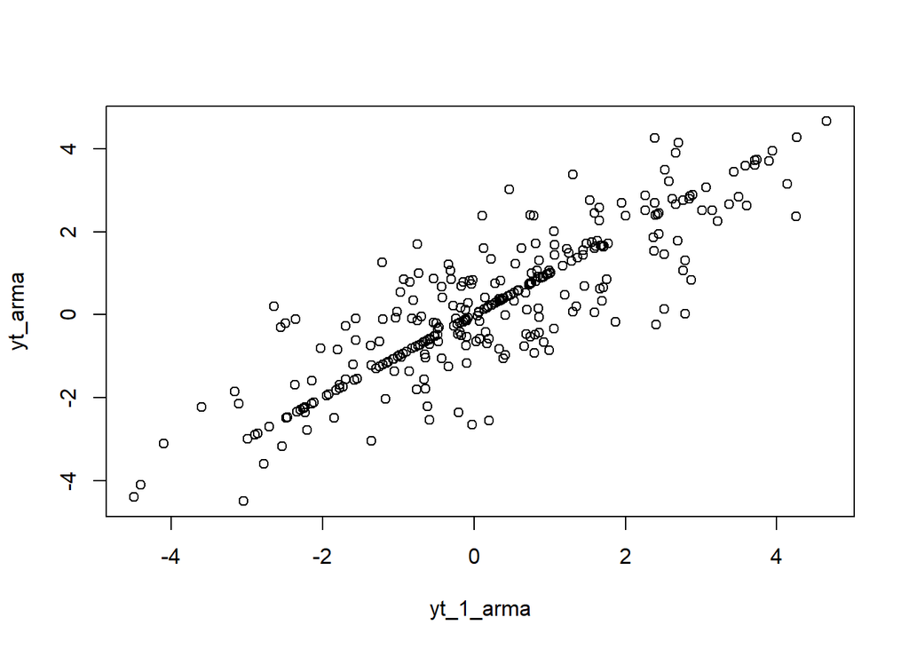

```r
plot(y=yt_arma,x=yt_1_arma)
```

Berdasarkan scatterplot tersebut, terlihat bahwa terdapat hubungan positif antara $Y_t$ dengan $Y_{t-1}$. Hal ini sesuai dengan teori yang ada.

### Korelasi antara $Y_t$ dengan $Y_{t-2}$

```r
#Yt
yt2_arma <- arma22[-c(1,2)]
yt2_arma
```

```
##   [1] -0.24246686 -0.09833948 -1.17223489 -2.03060488 -0.80484470  0.35416729
##   [7]  0.81727989  1.71535244  1.65327968  2.26628412  2.87143088  0.84349311
##  [13]  0.92513572 -0.66330571 -1.56027505 -0.61434833 -2.20571610 -2.77875558
##  [19] -3.60298132 -2.23099833 -2.36322256 -1.69560501 -1.56161999 -0.09860517
##  [25] -0.53709823  0.86256867 -0.42908366 -1.05595588 -1.36716541 -0.74599309
##  [31] -0.14443797  0.79377285 -0.93219702  0.85870083 -0.06220909  0.81522712
##  [37]  0.81037637 -0.47950596 -0.33858754 -1.25146380 -0.65481150 -0.96012669
##  [43] -1.01742774  0.07231702 -0.16512118  0.68675575 -0.47589465 -0.64568813
##  [49] -1.03416598 -0.08293220  0.27575224  0.74624311 -0.53653035 -0.18566371
##  [55] -0.42408042  0.67735218  0.53267634  0.33073256 -0.82044851 -0.09969010
##  [61] -0.13956357 -0.16683189 -0.50155894 -0.21522035 -0.46148282 -0.31285443
##  [67]  1.06370729  1.44019539  1.56090694  1.75331494  0.85484590  0.15005524
##  [73] -0.41613044  0.41092792 -0.01938142  0.83582053  1.06944093  1.68738409
##  [79]  1.66670135  0.62841476  1.60858305  1.65586404  2.57582443  3.22003517
##  [85]  2.26048313  2.51739847  0.14052150  0.41076757 -0.96927417  0.54497556
```

[output cut: 35 more lines]

```r
#Yt-2
yt_2_arma <- arma22[-c(200,199)]
yt_2_arma
```

```
##   [1]  0.74304034  2.40422722 -0.24246686 -0.09833948 -1.17223489 -2.03060488
##   [7] -0.80484470  0.35416729  0.81727989  1.71535244  1.65327968  2.26628412
##  [13]  2.87143088  0.84349311  0.92513572 -0.66330571 -1.56027505 -0.61434833
##  [19] -2.20571610 -2.77875558 -3.60298132 -2.23099833 -2.36322256 -1.69560501
##  [25] -1.56161999 -0.09860517 -0.53709823  0.86256867 -0.42908366 -1.05595588
##  [31] -1.36716541 -0.74599309 -0.14443797  0.79377285 -0.93219702  0.85870083
##  [37] -0.06220909  0.81522712  0.81037637 -0.47950596 -0.33858754 -1.25146380
##  [43] -0.65481150 -0.96012669 -1.01742774  0.07231702 -0.16512118  0.68675575
##  [49] -0.47589465 -0.64568813 -1.03416598 -0.08293220  0.27575224  0.74624311
##  [55] -0.53653035 -0.18566371 -0.42408042  0.67735218  0.53267634  0.33073256
##  [61] -0.82044851 -0.09969010 -0.13956357 -0.16683189 -0.50155894 -0.21522035
##  [67] -0.46148282 -0.31285443  1.06370729  1.44019539  1.56090694  1.75331494
##  [73]  0.85484590  0.15005524 -0.41613044  0.41092792 -0.01938142  0.83582053
##  [79]  1.06944093  1.68738409  1.66670135  0.62841476  1.60858305  1.65586404
##  [85]  2.57582443  3.22003517  2.26048313  2.51739847  0.14052150  0.41076757
```

[output cut: 35 more lines]

### Plot

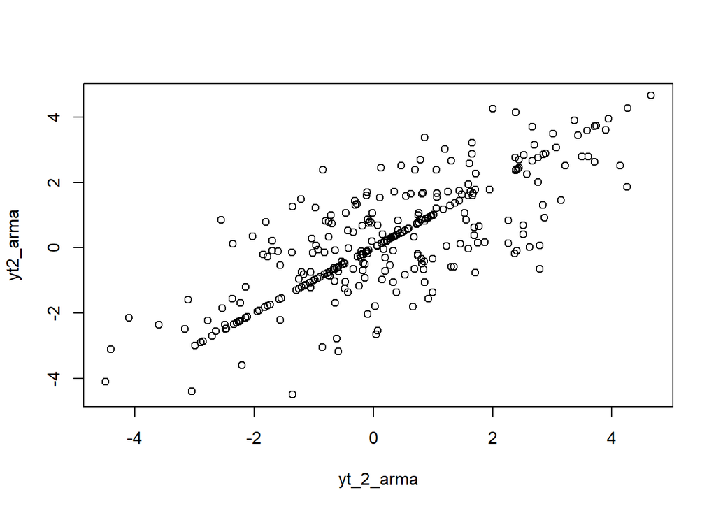

```r
plot(y=yt2_arma,x=yt_2_arma)
```

Berdasarkan scatterplot tersebut, terlihat bahwa terdapat hubungan positif antara $Y_t$ dengan $Y_{t-2}$. Hal ini sesuai dengan teori yang ada.

### Korelasi antara $Y_t$ dengan $Y_{t-3}$

```r
#Yt
yt3_arma <- arma22[-c(1,2,3)]
yt3_arma
```

```
##   [1] -0.09833948 -1.17223489 -2.03060488 -0.80484470  0.35416729  0.81727989
##   [7]  1.71535244  1.65327968  2.26628412  2.87143088  0.84349311  0.92513572
##  [13] -0.66330571 -1.56027505 -0.61434833 -2.20571610 -2.77875558 -3.60298132
##  [19] -2.23099833 -2.36322256 -1.69560501 -1.56161999 -0.09860517 -0.53709823
##  [25]  0.86256867 -0.42908366 -1.05595588 -1.36716541 -0.74599309 -0.14443797
##  [31]  0.79377285 -0.93219702  0.85870083 -0.06220909  0.81522712  0.81037637
##  [37] -0.47950596 -0.33858754 -1.25146380 -0.65481150 -0.96012669 -1.01742774
##  [43]  0.07231702 -0.16512118  0.68675575 -0.47589465 -0.64568813 -1.03416598
##  [49] -0.08293220  0.27575224  0.74624311 -0.53653035 -0.18566371 -0.42408042
##  [55]  0.67735218  0.53267634  0.33073256 -0.82044851 -0.09969010 -0.13956357
##  [61] -0.16683189 -0.50155894 -0.21522035 -0.46148282 -0.31285443  1.06370729
##  [67]  1.44019539  1.56090694  1.75331494  0.85484590  0.15005524 -0.41613044
##  [73]  0.41092792 -0.01938142  0.83582053  1.06944093  1.68738409  1.66670135
##  [79]  0.62841476  1.60858305  1.65586404  2.57582443  3.22003517  2.26048313
##  [85]  2.51739847  0.14052150  0.41076757 -0.96927417  0.54497556  1.22269581
```

[output cut: 35 more lines]

```r
#Yt-3
yt_3_arma <- arma22[-c(200,199,198)]
yt_3_arma
```

```
##   [1]  0.74304034  2.40422722 -0.24246686 -0.09833948 -1.17223489 -2.03060488
##   [7] -0.80484470  0.35416729  0.81727989  1.71535244  1.65327968  2.26628412
##  [13]  2.87143088  0.84349311  0.92513572 -0.66330571 -1.56027505 -0.61434833
##  [19] -2.20571610 -2.77875558 -3.60298132 -2.23099833 -2.36322256 -1.69560501
##  [25] -1.56161999 -0.09860517 -0.53709823  0.86256867 -0.42908366 -1.05595588
##  [31] -1.36716541 -0.74599309 -0.14443797  0.79377285 -0.93219702  0.85870083
##  [37] -0.06220909  0.81522712  0.81037637 -0.47950596 -0.33858754 -1.25146380
##  [43] -0.65481150 -0.96012669 -1.01742774  0.07231702 -0.16512118  0.68675575
##  [49] -0.47589465 -0.64568813 -1.03416598 -0.08293220  0.27575224  0.74624311
##  [55] -0.53653035 -0.18566371 -0.42408042  0.67735218  0.53267634  0.33073256
##  [61] -0.82044851 -0.09969010 -0.13956357 -0.16683189 -0.50155894 -0.21522035
##  [67] -0.46148282 -0.31285443  1.06370729  1.44019539  1.56090694  1.75331494
##  [73]  0.85484590  0.15005524 -0.41613044  0.41092792 -0.01938142  0.83582053
##  [79]  1.06944093  1.68738409  1.66670135  0.62841476  1.60858305  1.65586404
##  [85]  2.57582443  3.22003517  2.26048313  2.51739847  0.14052150  0.41076757
```

[output cut: 35 more lines]

### Plot

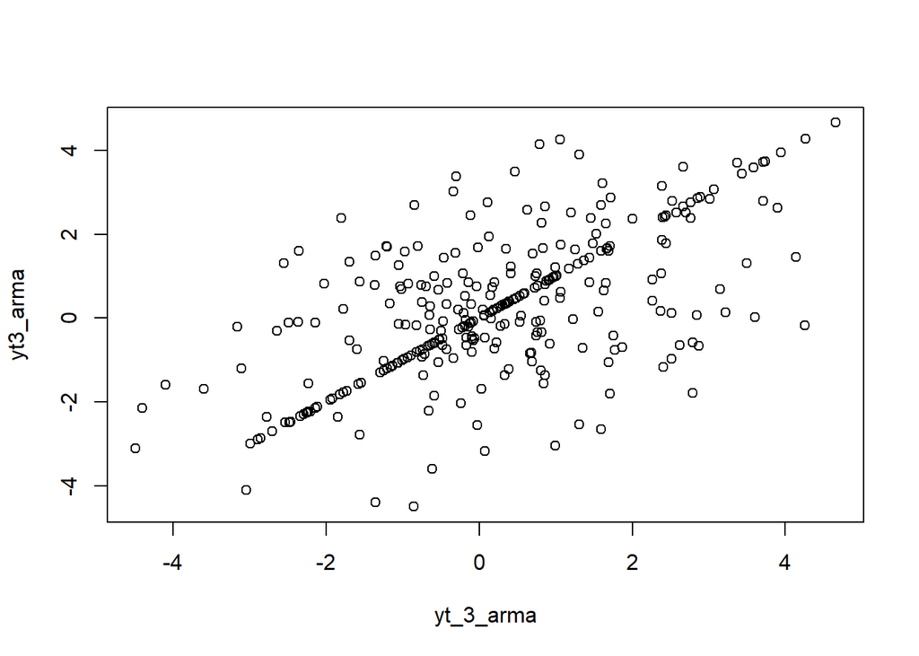

```r
plot(y=yt3_arma,x=yt_3_arma)
```

Berdasarkan scatterplot tersebut, terlihat bahwa terdapat hubungan positif antara $Y_t$ dengan $Y_{t-3}$. Hal ini sesuai dengan teori yang ada

```r
cor(yt_arma,yt_1_arma)
```

```
## [1] 0.8570346
```

```r
cor(yt2_arma,yt_2_arma)
```

```
## [1] 0.7772623
```

```r
cor(yt3_arma,yt_3_arma)
```

```
## [1] 0.5938008
```